# Bargaining and Conflict

## Introduction

## Overview

- Earlier this term: perhaps war is in our genes?
- Today: could two rational, unitary actors fight?
  - The rationalist puzzle of war
  - Three mechanisms for war
  - Credible threats
- Next week: relax the unitary actor assumption

## Today's puzzle

Why are sanctions typically unsuccessful in producing compliance with demands (substantial concessions by target only in 20-30% of cases)?

## The Rationalist Puzzle of War

## The Puzzle

- War is an inefficient way of settling disputes. War always appears inefficient ex post.
- Why, then, does it recur? I.e., why does it not always seem inefficient ex ante?
- Why would two *rational* actors fight?

## Explanation 1: Anarchy

- Waltz: *"In the absence of a supreme authority there is then the constant possibility that conflicts will be settled by force"* (1959, p. 188).
- But if using force is a costly option, why is it ever used? I.e., how does the lack of a central authority prevent states from negotiating agreements both sides would prefer to fighting?

## Explanation 2: Preventive war

- A decline in power would lead the declining power to attack now
- Typical story: uncertainty about future motivations

## Explanation 3: Positive expected utility

- But again, this does not address the problem!
- The question is: when will there be bargains that both prefer to war? I.e., can both states have a positive expected utility?

## Why States might fail to find the ex ante agreement?

## 1. Indivisibilities: the problem

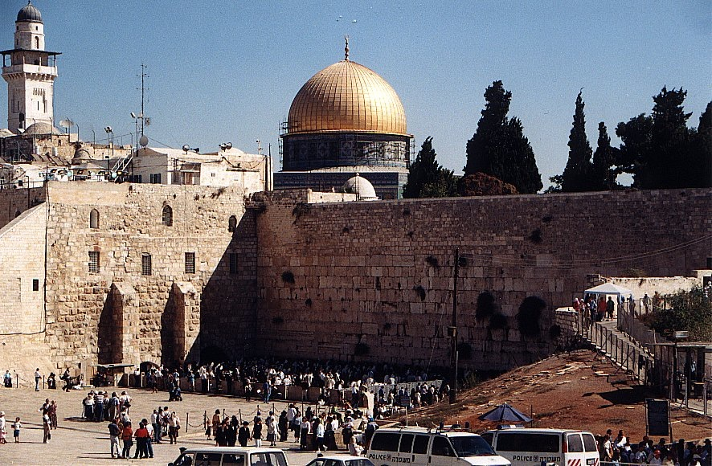

e.g., Jerusalem

## Indivisibilities: solutions

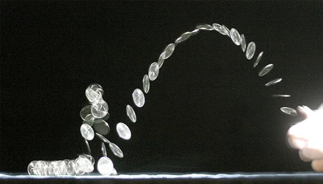

## 2. Commitment Problems

[figure not shown]

J.W. Waterhouse: "Ulysses and the Sirens"

## Commitment problems: Solutions

- Trust-building
- Withdraw troops from border
- Negotiate disarmament
  - E.g. Washington naval treaty
- Compensation
  - E.g. partition of Poland

## 3. Private Information and Incentives to Misrepresent

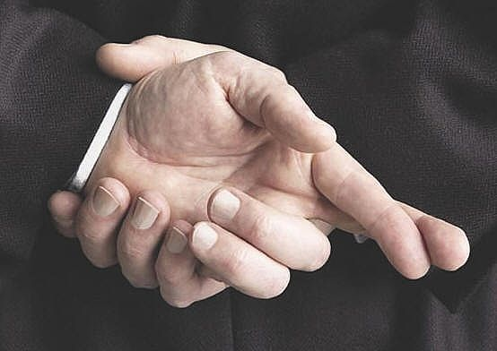

- Intelligence
- Mediation
- Costly signals

A major problem is that the states' messages are cheap talk. I.e., they convey no information

## Credible Threats

## A Simple Game

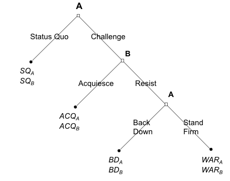

## Slippery Slope

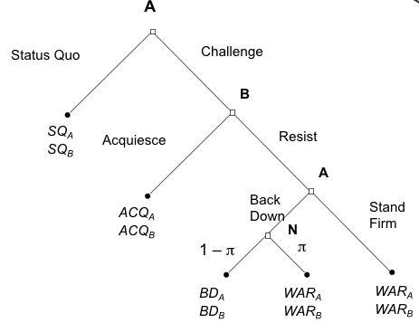

Slippery Slope

## Tying Hands

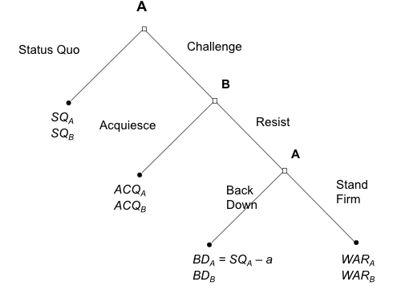

Tying Hands

## Sunk Costs

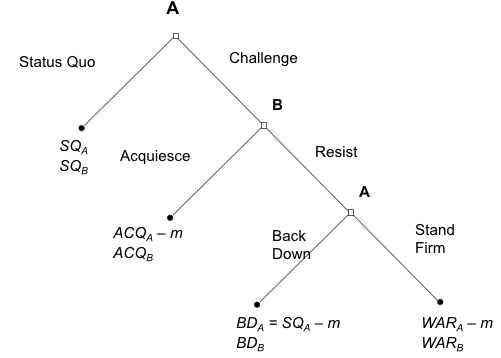

Sunk Costs

## Conclusion

## Review

- Fundamental puzzle: War is an inefficient way of allocating resources. Why does it occur?
- 3 rationalist explanations for war
  - Indivisibilities
  - Commitment problems
  - Incomplete Information
- Importance of signals

## Answer to today's puzzle

Puzzle: Why are sanctions typically unsuccessful in producing compliance with demands (substantial concessions by target only in 20-30% of cases)?

Answer:

- Rally around the flag
- Selection effects: if the target believes it will have to comply eventually, it may do so before the sanctions are applied Sanctions do not occur when they work; when they occur, they do not work
- States use sanctions on issues when they are unwilling to bear the cost of military action. Sanctions signal relative lack of resolve by the sanctioning state
- The target's regime influences its leader's vulnerability to economic pressure.